# Bank Loan Prediction

#### The objective of this project was to predict and give recommendation whether or not the loan should be granted based on data. In this project, the data will be cleaned and prepped, and a model will be build to acheive accuracy.

## Before we begin: Import and Load Data

```python
import pandas as pd
import seaborn as sns
import numpy as np

import matplotlib.pyplot as plt
%matplotlib inline

from py import path
import math

import statsmodels.api as sm
from sklearn.model_selection import train_test_split
from sklearn.ensemble import RandomForestRegressor
from sklearn.ensemble import RandomForestClassifier
from sklearn.metrics import accuracy_score
```

```python
df = pd.read_csv(path.local('loan prediction data files/LoansTrainingSet.csv'),low_memory=False)
```

## Data Exploration

```python
df.head(2)
```

|  | Loan ID | Customer ID | Loan Status | Current Loan Amount | Term | Credit Score | Years in current job | Home Ownership | Annual Income | Purpose | Monthly Debt | Years of Credit History | Months since last delinquent | Number of Open Accounts | Number of Credit Problems | Current Credit Balance | Maximum Open Credit | Bankruptcies | Tax Liens |
| --- | --- | --- | --- | --- | --- | --- | --- | --- | --- | --- | --- | --- | --- | --- | --- | --- | --- | --- | --- |
| 0 | 000025bb-5694-4cff-b17d-192b1a98ba44 | 5ebc8bb1-5eb9-4404-b11b-a6eebc401a19 | Fully Paid | 11520 | Short Term | 741.0 | 10+ years | Home Mortgage | 33694.0 | Debt Consolidation | $584.03 | 12.3 | 41.0 | 10 | 0 | 6760 | 16056 | 0.0 | 0.0 |
| 1 | 00002c49-3a29-4bd4-8f67-c8f8fbc1048c | 927b388d-2e01-423f-a8dc-f7e42d668f46 | Fully Paid | 3441 | Short Term | 734.0 | 4 years | Home Mortgage | 42269.0 | other | $1,106.04 | 26.3 | NaN | 17 | 0 | 6262 | 19149 | 0.0 | 0.0 |

```python
df.info()
```

```
<class 'pandas.core.frame.DataFrame'>
RangeIndex: 256984 entries, 0 to 256983
Data columns (total 19 columns):
Loan ID                         256984 non-null object
Customer ID                     256984 non-null object
Loan Status                     256984 non-null object
Current Loan Amount             256984 non-null int64
Term                            256984 non-null object
Credit Score                    195308 non-null float64
Years in current job            256984 non-null object
Home Ownership                  256984 non-null object
Annual Income                   195308 non-null float64
Purpose                         256984 non-null object
Monthly Debt                    256984 non-null object
Years of Credit History         256984 non-null float64
Months since last delinquent    116601 non-null float64
Number of Open Accounts         256984 non-null int64
Number of Credit Problems       256984 non-null int64
Current Credit Balance          256984 non-null int64
Maximum Open Credit             256984 non-null object
Bankruptcies                    256455 non-null float64
Tax Liens                       256961 non-null float64
dtypes: float64(6), int64(4), object(9)
memory usage: 37.3+ MB
```

```python
df.isnull().sum()
```

```
Loan ID                              0
Customer ID                          0
Loan Status                          0
Current Loan Amount                  0
Term                                 0
Credit Score                     61676
Years in current job                 0
Home Ownership                       0
Annual Income                    61676
Purpose                              0
Monthly Debt                         0
Years of Credit History              0
Months since last delinquent    140383
Number of Open Accounts              0
Number of Credit Problems            0
Current Credit Balance               0
Maximum Open Credit                  0
Bankruptcies                       529
Tax Liens                           23
dtype: int64
```

```python
df.describe()
```

|  | Current Loan Amount | Credit Score | Annual Income | Years of Credit History | Months since last delinquent | Number of Open Accounts | Number of Credit Problems | Current Credit Balance | Bankruptcies | Tax Liens |
| --- | --- | --- | --- | --- | --- | --- | --- | --- | --- | --- |
| count | 2.569840e+05 | 195308.000000 | 1.953080e+05 | 256984.000000 | 116601.000000 | 256984.000000 | 256984.000000 | 2.569840e+05 | 256455.000000 | 256961.000000 |
| mean | 1.371331e+07 | 1251.116099 | 7.195272e+04 | 18.290195 | 34.881450 | 11.106267 | 0.156628 | 1.540656e+04 | 0.110316 | 0.027203 |
| std | 3.438131e+07 | 1762.016848 | 5.887757e+04 | 7.075747 | 21.854165 | 4.982982 | 0.460731 | 1.966506e+04 | 0.336229 | 0.245950 |
| min | 5.050000e+02 | 585.000000 | 0.000000e+00 | 3.400000 | 0.000000 | 0.000000 | 0.000000 | 0.000000e+00 | 0.000000 | 0.000000 |
| 25% | 8.299000e+03 | 714.000000 | 4.432100e+04 | 13.500000 | 16.000000 | 8.000000 | 0.000000 | 5.974000e+03 | 0.000000 | 0.000000 |
| 50% | 1.429800e+04 | 733.000000 | 6.124200e+04 | 17.000000 | 32.000000 | 10.000000 | 0.000000 | 1.107800e+04 | 0.000000 | 0.000000 |
| 75% | 2.436700e+04 | 744.000000 | 8.646200e+04 | 21.700000 | 51.000000 | 14.000000 | 0.000000 | 1.931900e+04 | 0.000000 | 0.000000 |
| max | 1.000000e+08 | 7510.000000 | 8.713547e+06 | 70.500000 | 176.000000 | 76.000000 | 11.000000 | 1.731412e+06 | 7.000000 | 11.000000 |

```python
ct_LoanStatus_Term = pd.crosstab(index=df['Loan Status'], columns=[df['Term']], normalize='columns')
ct_LoanStatus_Term
```

| Term Loan Status | Long Term | Short Term |
| --- | --- | --- |
| Charged Off | 0.462037 | 0.265065 |
| Fully Paid | 0.537963 | 0.734935 |

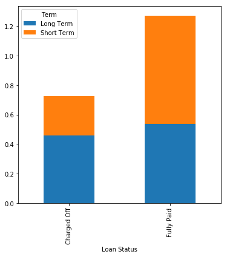

```python
ct_LoanStatus_Term.plot(kind='bar', figsize=(6,6), stacked=True)
```

## Data Clearning

#### Credit Score: Some credit score is invalid where score is > 850. Therefore, I'll devide them by 10.

```
Invalid Scores:
```

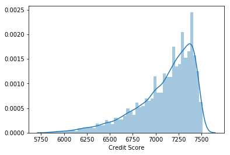

```python
invalid_cred = df[df['Credit Score'].notnull()]
invalid_cred = invalid_cred[(invalid_cred['Credit Score'] > 850)]
print('Invalid Scores:')
sns.distplot(invalid_cred['Credit Score']);
```

```
Score distribution after transformation:
```

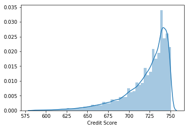

```python
df['Credit Score'] = df['Credit Score'].apply(lambda x: x/10 if x > 850 else x) #apply transformation
print('Score distribution after transformation:')
sns.distplot(df[df['Credit Score'].notnull()]['Credit Score']);
```

#### Purpose: there are duplicate values - 'other' and 'Other'. I'll change them all into 'Other'.

```python
ct_Term_Purpose = pd.crosstab(index=df['Term'], columns=[df['Purpose']], normalize='columns')
ct_Term_Purpose
```

| Purpose Term | Business Loan | Buy House | Buy a Car | Debt Consolidation | Educational Expenses | Home Improvements | Medical Bills | Other | Take a Trip | other |
| --- | --- | --- | --- | --- | --- | --- | --- | --- | --- | --- |
| Long Term | 0.262946 | 0.269281 | 0.20757 | 0.258358 | 0.067416 | 0.274086 | 0.177127 | 0.183718 | 0.077707 | 0.198136 |
| Short Term | 0.737054 | 0.730719 | 0.79243 | 0.741642 | 0.932584 | 0.725914 | 0.822873 | 0.816282 | 0.922293 | 0.801864 |

```python
df['Purpose'] = df['Purpose'].replace('other', 'Other')
ct_Term_Purpose = pd.crosstab(index=df['Term'], columns=[df['Purpose']], normalize='columns')
ct_Term_Purpose
```

| Purpose Term | Business Loan | Buy House | Buy a Car | Debt Consolidation | Educational Expenses | Home Improvements | Medical Bills | Other | Take a Trip |
| --- | --- | --- | --- | --- | --- | --- | --- | --- | --- |
| Long Term | 0.262946 | 0.269281 | 0.20757 | 0.258358 | 0.067416 | 0.274086 | 0.177127 | 0.192313 | 0.077707 |
| Short Term | 0.737054 | 0.730719 | 0.79243 | 0.741642 | 0.932584 | 0.725914 | 0.822873 | 0.807687 | 0.922293 |

#### Home Ownership: There are duplicate values - 'HaveMortgage' and 'Home Mortgage'. I'll change them into 'Home Mortgage'.

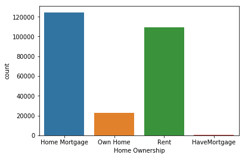

```python
sns.countplot(x='Home Ownership',data=df);
```

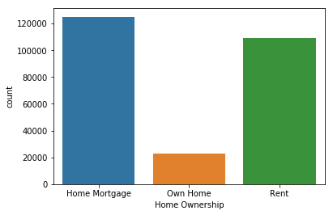

```python
df['Home Ownership'] = df['Home Ownership'].replace('HaveMortgage', 'Home Mortgage')
sns.countplot(x='Home Ownership',data=df)
```

#### Maximum Open Credit: Some value is '#VALUE!' instead of float. Therefore, Maximum Open Credit is classified as object instead of floot. Therefore, I'll replace '#VALUE!' with 0 and change its type to floot.

```python
df['Maximum Open Credit'][df['Maximum Open Credit']=='#VALUE!']
```

```
184662    #VALUE!
184663    #VALUE!
187512    #VALUE!
187513    #VALUE!
Name: Maximum Open Credit, dtype: object
```

```python
df['Maximum Open Credit'] = df['Maximum Open Credit'].replace('#VALUE!', 0).astype(float)
df['Maximum Open Credit'].head(2)
```

```
0    16056.0
1    19149.0
Name: Maximum Open Credit, dtype: float64
```

#### Monthly Debt: Value are object because of its Dollar Sign and Comma. I'll make the adjustment and change data type to float.

```python
df['Monthly Debt'].head(5)
```

```
0       $584.03
1    $1,106.04
2    $1,321.85
3       $751.92
4       $355.18
Name: Monthly Debt, dtype: object
```

```python
df['Monthly Debt'] = df['Monthly Debt'].str.strip('$')
df['Monthly Debt'] = df['Monthly Debt'].replace(',', '', regex=True).astype(float)
df['Monthly Debt'].head(5)
```

```
0     584.03
1    1106.04
2    1321.85
3     751.92
4     355.18
Name: Monthly Debt, dtype: float64
```

#### Years in current job: Convert to float.

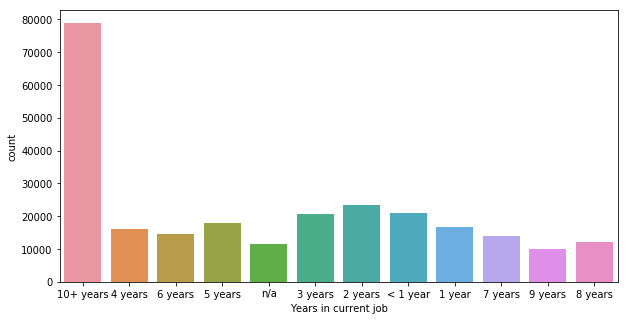

```python
plt.figure(figsize=(10,5))
sns.countplot(x='Years in current job',data=df);
```

```python
df['Years in current job'] = df['Years in current job'].str.strip('+ years')
df['Years in current job'] = df['Years in current job'].replace('n/', -1)
df['Years in current job'] = df['Years in current job'].replace('< 1', 0).astype(int)
```

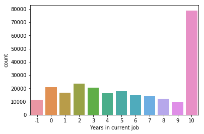

```python
sns.countplot(x='Years in current job',data=df);
```

#### Current Loan Amount: There is an outlier of 99999999. Replace it with 0.

```python
df['Current Loan Amount'].max()
```

```
99999999
```

```python
countOfOutliers = df['Current Loan Amount'][df['Current Loan Amount']==df['Current Loan Amount'].max()].count()
countOfOutliers
```

```
35210
```

```python
print('Percentage of outliers:','{:.1%}'.format(countOfOutliers/df['Current Loan Amount'].count()))
```

```
Percentage of outliers: 13.7%
```

```python
df['Current Loan Amount'] = df['Current Loan Amount'].apply(lambda x: 0 if x == 99999999 else x) #apply transformation
df['Current Loan Amount'].max()
```

```
41000
```

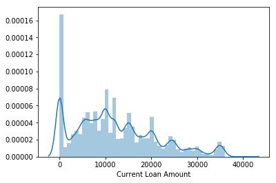

```python
sns.distplot(df['Current Loan Amount']);
```

## Filling Missing Values

#### Now all data are cleaned. I can start filling the missing values.

```python
df.isnull().sum()
```

```
Loan ID                              0
Customer ID                          0
Loan Status                          0
Current Loan Amount                  0
Term                                 0
Credit Score                     61676
Years in current job                 0
Home Ownership                       0
Annual Income                    61676
Purpose                              0
Monthly Debt                         0
Years of Credit History              0
Months since last delinquent    140383
Number of Open Accounts              0
Number of Credit Problems            0
Current Credit Balance               0
Maximum Open Credit                  0
Bankruptcies                       529
Tax Liens                           23
dtype: int64
```

#### Credit Score: fill with medians.

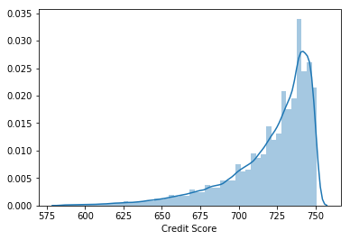

```python
sns.distplot(df['Credit Score'][df['Credit Score'].notnull()])
```

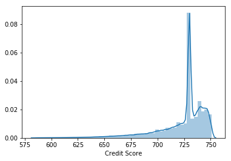

```python
df['Credit Score'] = df['Credit Score'].fillna(df['Credit Score'].median())
sns.distplot(df['Credit Score'])
```

#### Annual Income: fill with median values.

```python
df['Annual Income'] = df['Annual Income'].fillna(df['Annual Income'].median())
```

#### Bankruptcies: fill with 0. Because majority of people do not have bankruptcies.

```python
df['Bankruptcies'] = df['Bankruptcies'].fillna(0)
```

#### Tax Liens: fill with 0.

```python
df['Tax Liens'] = df['Tax Liens'].fillna(0)
```

#### Months since last delinquent: I'll fill it with respect to credit score using a Random Forest Regressor.

#### First, bin 'Credit Score' into 4 bins:

1. x < 630
2. 630 <= x < 690
3. 690 <= x < 720
4. 720 <= x

```python
df['credit_bad'] = df['Credit Score'].map(lambda x: 1 if x<630 else 0)
df['credit_fair'] = df['Credit Score'].map(lambda x: 1 if 630<=x<690 else 0)
df['credit_good'] = df['Credit Score'].map(lambda x: 1 if 690<=x<720 else 0)
df['credit_excellent'] = df['Credit Score'].map(lambda x: 1 if 720<=x else 0)
```

```python
df_credit = df[['Months since last delinquent', 'Credit Score',
                'credit_bad', 'credit_fair', 'credit_good', 'credit_excellent']]
df_credit.head(3)
```

|  | Months since last delinquent | Credit Score | credit_bad | credit_fair | credit_good | credit_excellent |
| --- | --- | --- | --- | --- | --- | --- |
| 0 | 41.0 | 741.0 | 0 | 0 | 0 | 1 |
| 1 | NaN | 734.0 | 0 | 0 | 0 | 1 |
| 2 | NaN | 747.0 | 0 | 0 | 0 | 1 |

```python
xy_train = df_credit.loc[df['Months since last delinquent'].notnull()]
xy_test = df_credit.loc[df['Months since last delinquent'].isnull()]

x_train = xy_train.values[:,1::]
y_train = xy_train.values[:,0]

x_test = xy_test.values[:,1::]

rf = RandomForestRegressor(n_estimators=200)
rf.fit(x_train,y_train)
y_pred = rf.predict(x_test)

df.loc[(df['Months since last delinquent'].isnull()), 'month_since_last_delinquent'] = y_pred
df['month_since_last_delinquent'] = np.where(np.isnan(df['month_since_last_delinquent']),
                                            df['Months since last delinquent'],
                                             df['month_since_last_delinquent'])
df.drop('Months since last delinquent', axis=1, inplace=True)
```

#### There are no more missing values:

```python
df.isnull().sum().sum()
```

```
0
```

## Feature Engineering

#### Generate Categorical var for some vars

```python
df['bankrupted'] = df['Bankruptcies'].map(lambda x: 1 if x > 0 else 0)
df['had_tax_leins'] = df['Tax Liens'].map(lambda x: 1 if x > 0 else 0)
df['no_credit_problems'] = df['Number of Credit Problems'].map(lambda x: 1 if x == 0 else 0)
df['not_debt_consolidation'] = df['Purpose'].map(lambda x: 0 if x == 'Debt Consolidation' else 1)
```

#### good_ratio: where 'Monthly Debt' * 12 / 'Annual Income < .3

```python
df['debt_to_income_ratio'] = (df['Monthly Debt'] * 12)/(df['Annual Income'])
df.debt_to_income_ratio = df.debt_to_income_ratio.apply(lambda x: 0 if math.isnan(x) else x)
df['good_ratio'] = df['debt_to_income_ratio'].map(lambda x: 1 if x < .3 else 0)
```

#### log(Years of Credit History) so that it is a better normal distribution

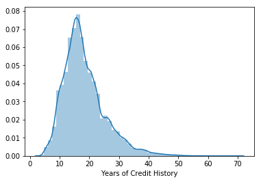

```python
sns.distplot(df['Years of Credit History']);
```

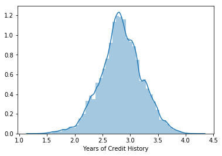

```python
df['Years of Credit History']=df['Years of Credit History'].map(lambda x: np.log(x))
sns.distplot(df['Years of Credit History'])
```

## Modeling

```python
print("There are", df.duplicated(['Loan ID', 'Customer ID']).sum(), "rows")
```

```
There are 41284 rows
```

```python
df1 = df.drop('Loan ID', 1)
df1 = df1.drop('Customer ID', 1)
```

```python
print("There are", df.duplicated(['Loan ID', 'Customer ID']).sum(), "rows")
```

```
There are 41284 rows
```

```python
df1 = pd.get_dummies(df1, drop_first=True)
```

```python
columns = pd.concat([df['Loan ID'], df['Customer ID']], axis=1)
df1 = pd.concat([columns, df1], axis=1)
df1 = df1.groupby('Loan ID').mean()
```

```python
y = df1['Loan Status_Fully Paid']
X = df1.drop(['Loan Status_Fully Paid'], axis=1)
```

```python
X_train, X_test, y_train, y_test = train_test_split(X, y, train_size=.6, test_size = .4)
```

```python
model = RandomForestClassifier(n_estimators=200)
model = model.fit(X_train, y_train)
pred = model.predict(X_test)
accuracy_score(pred, y_test)
```

```
0.86385025498377377
```